# week_5_abgabe

**Week 5: random walk and Entropy**

Jannek Schaffert, Frédéric Sonak

This markdown was created with the assistance of ChatGPT, focusing on grammar, spelling, and readability.

**Background**

In this homework, we investigated two fundamental concepts in statistical mechanics and complex systems: random walk and Entropy through two exercises: analyzing Gaussian distributions in random walks and exploring entropy production as a system evolves toward equilibrium.

In the first exercise, we examined the emergence of a Gaussian distribution from a random walk. By performing numerical simulations, one can observe how a Gaussian shape develops as the number of steps and independent walks increases. We calculated the distribution’s first three moments to highlight how these statistical properties depend on both the number of steps in each walk and the number of independent walks.

where $p_i(t)$ represents the probability of finding $i$ particles on the left (starting) side of the box. By running $M$ independent simulations, we calculated the number $n_k(t)$ of particles on the left side for each simulation and observed how $p_i(t)$ approached a Gaussian distribution centered around $i=N/2$ at long times. For simplicity, we set Boltzmann’s constant $k_B = 1$.

As with previous excercises three classes are used to conveniently implement functions for future reference.

Importing all utilised libraries.

```python
import matplotlib.pyplot as plt
from matplotlib import animation, rc
from IPython.display import HTML

from numba import njit

import copy
import numpy as np
import scipy as scy
```

The first class, "Box", contains all functions related to creating the simulation box, adding particles, and managing their interactions. Most of these functions were carried over from previous exercises. The function "fill_particles" was extended with an option to just fill particles to the left side of the box. This will later be used in accordance with the theory outlined in the above background section.

We changed the way hard-spheres interact, using array operations to speed up the computation time. Everything is described in code comments. Additionally we fixed the bug of spheres getting stuck inside of the wall. Finally we implemented a function to fill the left side of the box with a grid

```python
class Box():
    """Box-class: defining a rectangular box-shape, in which Particles can roam. One corner is always (0,0)\n
    box         : 2-dimensional array of the two lengths of the x- and y-axis, corresponding to the boundaries of the box.\n
    particles   : a list of all particles in the box\n
    n_particles : the number of particles inside of the box
    """
    def __init__(self, box_size, n_Particles:int):
        """Initializing the Box-class\n
        box_size    : a 2-dimensional array of the two lengths of the x- and y-axis, corresponding to the boundaries of the box.\n
        n_Particles : an integer of the number of Particles in the box. Needed to initialize all arrays correctly
        """
        # constants
        self.c_6        = 6.2647225     # kg/mol  *  nm**8/ns**2
        self.c_12       = 9.847044e-3   # kg/mol  *  nm**14/ns**2
        self.kB         = 1.380e-23     # J/K
        self.avogadro   = 6.022e23      # 1/mol

        self.box_size       = box_size
        # Particles statistics are no longer stored in a separate class but in arrays, which allows for easier calculations
        self.particles_pos  = np.zeros((n_Particles,2))
        self.particles_vel  = np.zeros((n_Particles,2))
        self.particles_acc  = np.zeros((n_Particles,2))

        self.particles_r    = np.zeros(n_Particles)
        self.combined_radii = self.particles_r[:,np.newaxis] + self.particles_r[np.newaxis,:]
        self.particles_m    = np.zeros(n_Particles, dtype=float)

        # We use distance matrices for true distances (distances_mat) in x and y coords,
        # distances with ghost particles for cross boundary calculations (distance_ghost) in x and y coords
        # and the norm of the ghost_distances as a single float
        self.distance_mat   = np.zeros((n_Particles,n_Particles,2))
        self.distance_ghost = np.zeros((n_Particles,n_Particles,2))
        self.distance_abs   = np.zeros((n_Particles,n_Particles))
        self.distance_abs_ghost   = np.zeros((n_Particles,n_Particles))
        # A vectorial force matrix to store the forces between each pair of particles in both directions
        self.force_mat      = np.zeros((n_Particles,n_Particles,2))
        # Storing the energy types currently in the system
        self.potEnergy_mat  = np.zeros((n_Particles,n_Particles,2))
        self.kinEnergy_mat  = np.zeros((n_Particles,n_Particles))

        self.temp = 0 # K

        self.n_particles = n_Particles

    def __repr__(self):
        """printing for debugging"""
        return str("This is a box of size %0.2f by %0.2f" % (self.box_size[0],self.box_size[1]) + ", with %0.2f" % (self.n_particles) + " particles")

    def random_positions(self, axis, n_particles = 0) -> None:
        """return random positions for a number of particles (only one axis)\n
        axis        : either 0 or 1.     0 = x-axis, 1 = y-axis\n
        n_particles : the number of particles for which positions should be given; default self.n_particles\n
        returns     : array of random positions
        """
        if n_particles == 0:
            n_particles = self.n_particles
        rnd = np.random.rand(n_particles)*(self.box_size[axis]-0.5)
        return rnd

    def fixedtemp_velocities(self, target_temp):
        """Calculate initial velocities, so that the initial kinetic energy corresponds to a target temperature"""
        kin_energy = self.kB * target_temp
        velocities = np.sqrt(2 * (kin_energy/self.n_particles) / (self.particles_m / self.avogadro))
        return velocities

    def fill_particles(self, radius, mass, vel, angle = [], x = [], y = [], align = 'random', grid = np.zeros(2), target_temp = 300) -> None:
        """fills the particles-array with particles\n
        radius      : The radius of particles; either as array of length n for individual radii or int/float for a general radius\n
        vel         : The absolute velocity; either as array of length n for individual velocities or int/float for a uniform initial velocity\n
        angle       : The initial angles of the particles as array of length n for individual angles; default is uniformly distributed\n
        x,y         : initial positions as array of length n; default random positions 0.5 away from border; Only used when align = 'defined'\n
        align       : Type of Particle placement: random = random positions; grid = grid-like arrangement(needs corresponding grid argument); defined = as given by x,y input\n
        grid        : 2x2 array that defines how many Particles should be in the grid on the x- and y- axis. Take care of correct number of particles!
        """
        # filling radius and mass, if given as a number for all particles
        if type(radius) == int or type(radius) == float:
            self.particles_r = np.ones(self.n_particles)*radius
        else:
            self.particles_r = radius
        self.combined_radii = self.particles_r[:,np.newaxis] + self.particles_r[np.newaxis,:]
        if type(mass) == int or type(mass) == float:
            self.particles_m = np.ones(self.n_particles)*mass
        else:
            self.particles_m = mass

        # randomize the angles if not given
        if len(angle) == 0:
            angle = np.random.uniform(0,2 * np.pi, self.n_particles)
        # fill velocities if given as a number for all particles
        if type(vel) == int or type(vel) == float:
            vel = np.ones(self.n_particles)*vel
        elif type(vel) == str:
            vel = self.fixedtemp_velocities(target_temp)

        # calculate the coressponding velocities
        self.particles_vel[:,0] = np.sin(angle) * vel
        self.particles_vel[:,1] = np.cos(angle) * vel

        # check which particle arrangement should be choosen
        if align == 'random':
            self.particles_pos[:,0] = self.random_positions(0,self.n_particles)
            self.particles_pos[:,1] = self.random_positions(1,self.n_particles)

        elif align == 'grid':
            if np.prod(grid) == self.n_particles:
                # This monster is mainly the meshgrid of coordinates, adjusted to be the correct shape.
                # Additionally the entire grid is moved by 0.1 in x and y direction to avoid Particles directly on the edge
                # It is not an error, even if vsCode thinks so
                max_rad = np.max(self.particles_r)+0.01
                self.particles_pos[:,] = np.column_stack(np.array(np.meshgrid(np.linspace(0,self.box_size[0]-max_rad,num=grid[0],endpoint=False),
                                                                              np.linspace(0,self.box_size[1]-max_rad,num=grid[1],endpoint=False),
                                                                              indexing='ij')).reshape(2,self.n_particles)) + max_rad
            else:
                print('ERROR: Grid size does not match number of particles!')
            # self.forces = np.ones((self.n_particles, self.n_particles, 2))-1
        elif align == 'left-grid':
            if np.prod(grid) == self.n_particles:
                # This monster is mainly the meshgrid of coordinates, adjusted to be the correct shape.
                # Additionally, the entire grid is moved by 0.1 in x and y direction to avoid Particles directly on the edge
                # It is not an error, even if vsCode thinks so
                max_rad = np.max(self.particles_r)+0.01
                self.particles_pos[:,] = np.column_stack(np.array(np.meshgrid(np.linspace(0,self.box_size[0]/2-max_rad,num=grid[0],endpoint=False),
                                                                              np.linspace(0,self.box_size[1]-max_rad,num=grid[1],endpoint=False),
                                                                              indexing='ij')).reshape(2,self.n_particles)) + max_rad
            else:
                print('ERROR: Grid size does not match number of particles!')
            # self.forces = np.ones((self.n_particles, self.n_particles, 2))-1
        elif align == 'defined':
            self.particles_pos[:,0] = x
            self.particles_pos[:,1] = y
        self.calculate_temp()
        #print(self.temp)
```

```python
    def move(self, dt = 1., vel = []) -> None:
        """moving the particle in the direction, where the velocity-vector points.\n
        dt  : the time-step moving forward; default = 1\n
        vel : a velocity vector for moving in that direction during a time-step of one; default = self.vel
        """
        if len(vel) == 0:
            vel = self.particles_vel
        self.particles_pos += vel*dt

    def wrap_around(self) -> None:
        """For continuous borders, i.e. a particle that exits to the right is entering from the left and vice versa\n
        particles   : Particles, which should be wrapped; default self.particles\n
        returns     : array of particles with new positions
        """
        self.particles_pos = self.particles_pos % self.box_size

    def reflect(self) -> None:
        """Reflecting particles on the edges of the box, if the hull is touching\n
        """
        positive = self.particles_pos+self.particles_r[:,np.newaxis]
        negative = self.particles_pos-self.particles_r[:,np.newaxis]
        #print(positive, negative)
        self.particles_vel[np.asarray(np.logical_and(positive > self.box_size, self.particles_vel > 0)).nonzero()] *= -1
        self.particles_vel[np.asarray(np.logical_and(negative < 0, self.particles_vel < 0)).nonzero()] *= -1
        self.particles_pos = np.where(np.logical_and(positive > self.box_size, self.particles_vel > 0),
                                      self.particles_pos-2*np.abs(positive - self.box_size[np.newaxis,:]), self.particles_pos)
        self.particles_pos = np.where(np.logical_and(negative < 0, self.particles_vel < 0), self.particles_pos+2*np.abs(negative), self.particles_pos)

    def collide_all(self) -> None:
        """Collide all particles if they overlap."""
        self.calculate_distance_matrix()
        distance_abs_triangle = np.triu(self.distance_abs)
        collisions = np.where(np.where(distance_abs_triangle == 0, np.inf, distance_abs_triangle) < self.combined_radii)
        if collisions[0].size != 0:
            for i in range(collisions[0].size):
                # print(collisions[0][i],collisions[1][i],'collided with a distance of ', distance_abs_triangle[collisions[0][i],collisions[1][i]])

                # defining re-used variables
                vel = self.particles_vel[collisions[0][i]] - self.particles_vel[collisions[1][i]]  # particles[i].vx-particles[j].vx
                v_x = vel[0]
                v_y = vel[1]

                r_x = self.distance_mat[collisions[0][i],collisions[1][i],0]
                r_y = self.distance_mat[collisions[0][i],collisions[1][i],1]

                R = self.combined_radii[collisions[0][i],collisions[1][i]]
                # angle between x-axis and line between particles
                if r_x == 0:
                    phi = 0
                else:
                    phi = np.arctan(r_y/r_x)

                #calculating the time needed to travel back in two steps:
                sqrt = 2*np.sqrt((r_x*v_x+r_y*v_y)**2-(v_x**2+v_y**2)*(r_x**2+r_y**2-R**2))

                delta_t = -1*(-2*(r_x*v_x+r_y*v_y) + sqrt)/(2*(v_x**2+v_y**2))

                #solving the quadratic equation results in two solutions (one positive and one negative), we want the negative solution, for backwards time-travel
                if delta_t > 0:
                    delta_t = -1*(-2*(r_x*v_x+r_y*v_y) - sqrt)/(2*(v_x**2+v_y**2))

                # rewind time to just outside of the collision
                self.particles_pos[(collisions[0][i],collisions[1][i]),:] += vel*delta_t
                # only calculate once, used multiple times
                sin_phi = np.sin(phi)
                cos_phi = np.cos(phi)

                # Get the velocities of particles i and j as variables
                v1x, v1y = self.particles_vel[collisions[0][i],0], self.particles_vel[collisions[0][i],1]
                v2x, v2y = self.particles_vel[collisions[1][i],0], self.particles_vel[collisions[1][i],1]

                # Calculate the updated velocities using the provided formulas: https://hermann-baum.de/elastischer_stoss/
                # the tangental part stays the same, the normal part changes. This is done in transformed coordinates and then transformed directly back
                new_v1x = (v1x * sin_phi - v1y * cos_phi) * sin_phi + (v2x * cos_phi + v2y * sin_phi) * cos_phi
                new_v1y = (-v1x * sin_phi + v1y * cos_phi) * cos_phi + (v2x * cos_phi + v2y * sin_phi) * sin_phi
                new_v2x = (v2x * sin_phi - v2y * cos_phi) * sin_phi + (v1x * cos_phi + v1y * sin_phi) * cos_phi
                new_v2y = (-v2x * sin_phi + v2y * cos_phi) * cos_phi + (v1x * cos_phi + v1y * sin_phi) * sin_phi

                # Update the particles' velocities
                self.particles_vel[collisions[0][i],0], self.particles_vel[collisions[0][i],1] = new_v1x, new_v1y
                self.particles_vel[collisions[1][i],0], self.particles_vel[collisions[1][i],1] = new_v2x, new_v2y
                #print(particles[i],particles[j],'collided with a distance of ', distance)

                # finish this time_step, that was rewound previously and open the boundaries again with np.mod
                self.particles_pos[(collisions[0][i],collisions[1][i]),:] += vel*-1*delta_t


    def update_pos(self, dt) -> None:
        """Updates the position according to the velocity-verlet algorithm\n
        dt  : The time step used
        """
        self.particles_pos = self.particles_pos + self.particles_vel*dt + 1/2*(self.particles_acc*dt**2)
        # always wrap around...
        self.wrap_around()

    def update_vel_acc(self, dt, lammda) -> None:
        """Updates the velocities according to the velocity-verlet algorithm. Therefore the updated accelerations are needed.\n
        dt  : The time step used
        """
        new_acc = self.calculate_acc()
        self.particles_vel = (self.particles_vel + 0.5*(self.particles_acc + new_acc)*dt) * lammda
        self.particles_acc = new_acc
```

```python
    def calculate_acc(self):
        """Updates the accelerations according to the velocity-verlet algorithm\n
        """
        return np.sum(self.force_mat,axis=0)/self.particles_m[:,np.newaxis]

    def calculate_temp(self):
        """Updates the temperature of the system. For this a recalculation of the kinetic energies is necessary"""
        self.calculate_kinEnergy_matrix()
        self.temp = np.sum(self.kinEnergy_mat)/self.kB/self.avogadro

    def calculate_lammda(self, tau, target_temp, dt):
        """Calculates the lambda of the berendsen thermostat. If the temperature is zero, it gives back zero."""
        self.calculate_temp()
        if self.temp != 0:
            return np.sqrt(1 + (dt/tau)*(target_temp/self.temp - 1))
        else:
            print(f'temp is zero!!')
            return 0


    def update_step(self, target_temp, dt, thermostat = 'no', tau = 2e-3) -> None:
        """The heart of the velocity-verlet algoritm.\n
        dt  : The time step used
        """
        self.update_pos(dt)
        # Before calculating the new velocities/accelerations, the forces must be calculated, for which we need the distance_matrix
        self.calculate_distance_matrix()
        self.calculate_force_matrix()
        # if a thermostat is used, take a different lambda into account
        if thermostat == 'berends':
            lammda = self.calculate_lammda(tau, target_temp, dt)
        elif thermostat == 'no':
            lammda = 1
        self.update_vel_acc(dt, lammda)

    def md_step(self, dt):
        self.move(dt=dt)
        self.reflect()
        self.collide_all()
        self.reflect()


    def calculate_distance_matrix(self) -> None:
        """Calculates a matrix, containing x and y distances of all particles to all other particles in both directions.\n
        It is by nature not symmetric, but rather the upper triangle is negated and flipped"""
        self.distance_mat = self.particles_pos[np.newaxis, :, :] - self.particles_pos[:, np.newaxis, :] # shape: (n,n,2)

        # the ghost matrix is calculated to account for interactions that go over the boundary of the box.
        # This is adjusted, if the x or y distances is greater than half the box size, which makes the distance across boundaries shorter
        self.distance_ghost = np.where(self.distance_mat[:, :] > (0.5 * self.box_size),
                                       self.distance_mat[:, :] - self.box_size, self.distance_mat[:, :]) # shape: (n,n,2)
        self.distance_ghost = np.where(self.distance_ghost[:, :] < -(0.5 * self.box_size),
                                       self.distance_ghost[:, :] + self.box_size, self.distance_ghost[:, :]) # shape: (n,n,2)
        # The norm is calculated as well as the absolute distance between each Particle pair. Symmetric by nature
        self.distance_abs = np.linalg.vector_norm(self.distance_mat, axis = 2) # shape: (n,n)
        self.distance_abs_ghost = np.linalg.vector_norm(self.distance_ghost, axis = 2) # shape: (n,n)
        #self.distance_abs = np.where(self.distance_abs == 0, np.inf, self.distance_abs)

    def calculate_force_matrix(self) -> None:
        """Calculate the forces acting from each Particle onto each particle as a directional vector stored in a matrix"""
        distance_abs_newaxis = self.distance_abs[:, :, np.newaxis] # shape: (n,n,1); used for better matrix multiplication with numpy
        # We have to check for any distances of zero between Particles, which would not allow for any force-calculation
        # We set those forces to zero
        self.force_mat = np.where(distance_abs_newaxis != 0, (12*self.c_12/distance_abs_newaxis**14-6*
                                                              self.c_6/distance_abs_newaxis**8)*self.distance_ghost, 0)

    def calculate_potEnergy_matrix(self) -> None:
        """Calculate the potential energy of the system"""
        # Again we need to account for any division by zero
        self.potEnergy_mat = np.where(self.distance_abs != 0, (self.c_12/(self.distance_abs**12)-
                                                               self.c_6/(self.distance_abs**6)), 0) # shape: (n,n)

    def calculate_kinEnergy_matrix(self) -> None:
        """Calculate the current kinetic energy in the system."""
        self.kinEnergy_mat = 0.5 * self.particles_m * np.square(np.linalg.norm(self.particles_vel, axis=1)) # shape: (n) #could be optimized maybe? square of squareroot of squares

    def steepest_descent(self, distance = 0.05, counter = 100, accuracy = 1.):
        """Does a steepest descent search for this box to find an energetically optimal position.\n
        distance    : How far the particles should move in one time-step, default: for now 0.05nm; might change in the future - lower gives better results\n
        counter     : How many re-calculations of the forces should maximally happen, default: 100
        accuracy    : How accurat the end-position has to be to stop the search, default: 1
        """
        # store the potential energy of the system at each step
        pot_energies = []
        # calculate forces and energy for the initial time-step
        self.calculate_distance_matrix()
        self.calculate_force_matrix()
        self.calculate_potEnergy_matrix()
        pot_energies.append(self.potEnergy_mat)
        pot_energy_old = np.sum(self.potEnergy_mat)/2

        #counting upwards, relict from previous iteration. Dont want to change that now
        i = 0
        # run the while-loop until the counter is reached
        while i < counter:
            # Calculate the normalized direction to move in for all Particles
            move_direction = np.sum(self.force_mat,axis=0)
            move_direction = np.divide(move_direction,np.linalg.norm(move_direction))
            # Move in that direction until the bottom is reached
            pathway = True
            while pathway:
                self.move(dt=distance, vel=move_direction)
                self.calculate_distance_matrix()
                self.calculate_potEnergy_matrix()
```

```python
                pot_energy_new_mat = self.potEnergy_mat
                pot_energy_new = np.sum(pot_energy_new_mat)/2
                # Check wether next energy is lower than previous one
                if pot_energy_new < np.sum(pot_energies[-1])/2:
                    # save the new energies
                    pot_energies.append(pot_energy_new_mat)
                else:
                    # move backwards to the last place
                    self.move(dt=-distance, vel=move_direction)
                    # recalculate the forces
                    self.calculate_distance_matrix()
                    self.calculate_force_matrix()
                    # count upwards and recalculate the moving direction in the next while-loop-iteration
                    i += 1
                    pathway = False
            # Check wether a local minimum is reached either if the energies get smaller insignificantly
            # or the new energies never get lower (mostly due to a large step size, so the next valley is hit)
            if np.abs(pot_energy_old - np.sum(pot_energies[-1])/2) < accuracy or pot_energy_new == pot_energy_old:
                #print('Ending steepest descent; reached local minimum')
                i = counter + 1
            else:
                pot_energy_old = pot_energy_new
        # return list of all energies (e.g. for plotting)
        return pot_energies
```

The "Simulation class" encompasses all functions dealing with the execution of the simulation. Again, all functions have been already introduced in previous excercises.

```python
class Simulation:
    """Simulation class for everything related to simulating the particles in a box\n
    box         : The box object which should be simulated
    steps       : The number of integration steps to perform
    dt          : The length of one time step
    data_traj   : The trajectories of all particles
    """
    def __init__(self, box:Box, steps, dt, target_temp = 300) -> None:
        """Initializing the Simulation\n
    box         : The box object which should be simulated
    steps       : The number of integration steps to perform
    dt          : The length of one time step
    """
        self.box:Box = box
        self.steps = steps
        self.dt = dt
        self.target_temp = target_temp
        self.set_traj()

    def set_traj(self) -> None:
        """Initialize the trajectory-saving"""
        self.data_traj  = np.zeros((self.box.n_particles, 3, 2, self.steps+1))
        self.pot_energy = np.zeros((self.box.n_particles, self.box.n_particles, self.steps+1))
        self.kin_energy = np.zeros((self.box.n_particles, self.steps+1))
        self.temps      = np.zeros((self.steps+1))

    def run(self, force_type = 'lennard-jones') -> None:
        self.set_traj()
        if force_type == 'lennard-jones':
            # Save the initial configuration
            self.data_traj[:,0,:,0], self.data_traj[:,1,:,0], self.data_traj[:,2,:,0] = self.box.particles_pos, self.box.particles_vel, self.box.particles_acc
            self.box.calculate_distance_matrix()
            self.box.calculate_potEnergy_matrix()
            self.box.calculate_kinEnergy_matrix()
            self.pot_energy[:,:,0] = self.box.potEnergy_mat
            self.kin_energy[:,0] = self.box.kinEnergy_mat
            self.temps[0] = self.box.temp
            # Iterate through each step
            for i in range(self.steps):
                # do velocity verlet and save pos, vel and acc
                self.box.update_step(self.target_temp, self.dt, thermostat='berends')
                self.data_traj[:,0,:,i+1], self.data_traj[:,1,:,i+1], self.data_traj[:,2,:,i+1] = self.box.particles_pos, self.box.particles_vel, self.box.particles_acc
                # calculate energies and save those as well
                self.box.calculate_potEnergy_matrix()
                self.box.calculate_kinEnergy_matrix()
                self.pot_energy[:,:,i+1] = self.box.potEnergy_mat
                self.kin_energy[:,i+1] = self.box.kinEnergy_mat
                self.temps[i+1] = self.box.temp
        elif force_type == 'hard-spheres':
            # Save the initial configuration
            self.data_traj[:,0,:,0], self.data_traj[:,1,:,0], self.data_traj[:,2,:,0] = self.box.particles_pos, self.box.particles_vel, self.box.particles_acc
            # self.box.calculate_distance_matrix()
            self.box.calculate_kinEnergy_matrix()
            self.kin_energy[:,0] = self.box.kinEnergy_mat
            self.temps[0] = self.box.temp
            # Iterate through each step
            for i in range(self.steps):
                # do MD and save pos, vel and acc
                self.box.md_step(self.dt)
                self.data_traj[:,0,:,i+1], self.data_traj[:,1,:,i+1], self.data_traj[:,2,:,i+1] = self.box.particles_pos, self.box.particles_vel, self.box.particles_acc
                # calculate energies and save those as well
                self.box.calculate_kinEnergy_matrix()
                self.kin_energy[:,i+1] = self.box.kinEnergy_mat
                self.temps[i+1] = self.box.temp
```

The final class, the "Analysis" class houses all functions dealing with the analysis of the simulation.All functions have been introduced in previous excercises.

```python
class Analysis():
    def __init__(self, sim:Simulation) -> None:
        self.sim = sim

    def show_traj(self):
        """Shows a 2D-plot of all trajectories"""
        for data_traj_j in self.sim.data_traj:
            plt.plot(data_traj_j[0][0],data_traj_j[0][1],'-')
        plt.xlabel('position x')
        plt.ylabel('position y')

        plt.grid()
        plt.show()
    def setup(self):
        """setup the animation"""
        self.fig, self.ax = plt.subplots()

        self.ax.set_xlim((0, self.sim.box.box_size[0]))
        self.ax.set_ylim((0, self.sim.box.box_size[1]))

        plt.xlabel('position x')
        plt.ylabel('position y')

        # make the points in the plot the correct size according to the radius of the particles
        # use ax.transData.transform to convert radius size from particle to markerSize from pyplot
        desired_size_in_data_units = self.sim.box.particles_r[0]/6
        data_to_points = self.ax.transData.transform((desired_size_in_data_units, 0))-self.ax.transData.transform((0, 0))
        marker_size_in_points = data_to_points[0]


        self.dot, = self.ax.plot([], [], 'bo', ms=marker_size_in_points)

    def init_vid(self):
        """initialize the video"""
        self.dot.set_data([], [])
        return (self.dot,)
    # animation function. This is called sequentially

    def animate(self,i):
        """animate the video"""
        x = self.sim.data_traj[:,0,0,i]
        y = self.sim.data_traj[:,0,1,i]
        self.dot.set_data(x, y)
        return (self.dot,)

    def animation(self, save_pls = False):
        """create and save a video of the simulation"""
        self.setup()
        anim = animation.FuncAnimation(self.fig, self.animate, init_func=self.init_vid,
                                       frames=self.sim.steps, interval=2, blit=True)
        HTML(anim.to_html5_video())

        # uncomment if video should not be saved
        if save_pls:
            anim.save('animation.mp4', fps=30)

    def histogram_vel_axis(self, axis):
        """histogram of the x velocity"""
        a = []
        for i in range(self.sim.steps):
            for j in range(self.sim.box.n_particles):
                a.append((self.sim.data_traj)[j, 1, axis, i])

        plt.hist(a,bins=50)
        plt.xlabel('velocity x')
        plt.ylabel('occupancy')
        plt.show()

    def histogram_pos_axis(self, axis):
        list_for_histogramm = []
        for i in range(self.sim.steps):
            for j in range(self.sim.box.n_particles):
                list_for_histogramm.append((self.sim.data_traj)[j, 0, axis, i])

        plt.hist(list_for_histogramm,range=(0,self.sim.box.box_size[axis]),bins=10)
        plt.xlabel('position x')
        plt.ylabel('occupancy')
        plt.show()

    def histogram_pos_2d(self):
        """2d plot of the position distribution"""
        a = []
        for i in range(self.sim.steps):
            for j in range(self.sim.box.n_particles):
                a.append((self.sim.data_traj)[j, 0, 0, i])
        b = []
        for i in range(self.sim.steps):
            for j in range(self.sim.box.n_particles):
                b.append((self.sim.data_traj)[j, 0, 1, i])


        plt.hist2d(a, b, range=[[0,self.sim.box.box_size[0]],[0,self.sim.box.box_size[1]]], bins=10)
        plt.xlabel('position x')
        plt.ylabel('position y')
        plt.colorbar().set_label('occupancy')
        plt.show()

    def histogram_vel_abs(self):
        #0 = 0
        all_velocities = np.array([])
        for i in range(self.sim.steps):
            for j in range(self.sim.box.n_particles):
                velocity = np.sqrt((self.sim.data_traj[j, 1, 0, i])**2 + (self.sim.data_traj[j, 1, 1, i])**2)
                all_velocities = np.append(all_velocities,velocity)

        plt.hist(all_velocities,bins=100)
        plt.xlabel('velocity |v|')
        plt.ylabel('occupancy')
        plt.show()

    def histogram_vel_last2first(self, percent, axis = 0):
        # comparison of different iteration parts

        # first 10%
        a = []
        for i in range(int(percent * self.sim.steps)):
            for j in range(self.sim.box.n_particles):
                a.append(self.sim.data_traj[j, 1, axis, i])

        # last 10%
        b = []
        for i in range(int((1-percent) * self.sim.steps),self.sim.steps):
            for j in range(self.sim.box.n_particles):
                b.append(self.sim.data_traj[j, 1, axis, i])

        plt.hist(a,bins=10, label = 'first 10% iterations')
        plt.hist(b,bins=10, label = 'last 10% iterations', alpha=0.5)
        plt.xlabel('velocity x')
        plt.ylabel('occupancy')
        plt.legend()
        plt.show()

    def plot_energies(self, kin = True, pot = True, com = True):
        fig, ax = plt.subplots(figsize=(16, 9))

        if pot:
            ax.plot(np.linspace(0,self.sim.steps,self.sim.steps+1),
                    np.sum(np.sum(self.sim.pot_energy,axis=0),axis=0)/2,label='pot')
        if kin:
            ax.plot(np.linspace(0,self.sim.steps,self.sim.steps+1),
                    np.sum(self.sim.kin_energy,axis=0),label='kin')
        if com:
            ax.plot(np.linspace(0,self.sim.steps,self.sim.steps+1),np.sum(self.sim.kin_energy,axis=0)
                    +np.sum(np.sum(self.sim.pot_energy,axis=0),axis=0)/2,label='com')

        ax.set_xlabel('time [s]')
        ax.set_ylabel('energy [g/mol m/s]')

        plt.legend()

    def exercise_four(self):
        """Calculates the two values from the exercise sheet 4"""
        rel_mom = np.sum(np.linalg.norm(self.sim.data_traj[:,2,:,:], axis = 1)
                         *self.sim.box.particles_m[:,np.newaxis], axis = 0)**2
        uno = np.var(rel_mom)/(np.mean(rel_mom)**2)
        dos = np.var(self.sim.temps)/(np.mean(self.sim.temps)**2)
        return uno, dos
```

### Task IV

First we define N and M, representing the amount of particles(in a grid) and the amount of simulations to be analyzed. Additionally we set the number of steps to 300 in a box of 10x10nm.

```python
# Defining the grids of particles
N_grid = np.array([[2,2],[3,3],[4,4],[5,5],[6,6],[7,7],[8,8]])#,[9,9],[10,10]])
n_particles = np.prod(N_grid, axis=1)
M_simulation = np.array([5,25,50])
steps = 300
box_size = np.array([10,10])
n_particles
```

```
array([ 4,  9, 16, 25, 36, 49, 64])
```

Below entropy analysis functions were defined. These can be used to analyse the above simulation.

```python
def entropy_analysis(N_grid, M_simulation, steps, box_size):
    # initialize arrays
    entropy = np.zeros((N_grid.shape[0], M_simulation.shape[0],steps+1))
    different_grid_left = np.zeros((N_grid.shape[0], M_simulation.shape[0], M_simulation[-1],steps+1),dtype=object)
    different_grid_right = np.zeros((N_grid.shape[0], M_simulation.shape[0], M_simulation[-1],steps+1),dtype=object)
    # loop through the different arangements of particles
    for i, grid in enumerate(N_grid):
        n_particles = int(np.prod(grid))
        # initialize the box
        box = Box(box_size,n_particles)
        # loop through the different amount of total simulations
        for j, simulation in enumerate(M_simulation):
            # loop through the individual simulations
            for k in range(simulation):
                # (re)fill the box
                box.fill_particles(0.2,0.018,0.1,align='left-grid',grid=grid)
                # Initialize and run the simulation
                sim = Simulation(box,steps,1)
                sim.run(force_type='hard-spheres')
                # calculate the amount of particles in the left and right (the latter for sanity check)
                different_grid_left[i,j,k] = np.histogram(np.where(sim.data_traj[:,0,0,:]<box_size[0]/2)[1],bins = steps+1, range=(0,steps+1))[0]
                different_grid_right[i,j,k] = np.histogram(np.where(sim.data_traj[:,0,0,:]>=box_size[0]/2)[1],bins = steps+1, range=(0,steps+1))[0]
            # calculate the entropy for this configuration and each time step
            # There is a way to do is without the for loop and through vector operations.
            # But I'm feeling lazy
            for s in range(steps + 1):
                counts, _ = np.histogram(different_grid_left[i,j,:M_simulation[j],s], range(0,n_particles))
                entropy[i,j,s] = np.sum(np.where(counts!=0, counts*np.log(counts), 0))
    return different_grid_left, different_grid_right, entropy
```

```python
left, right, entropy = entropy_analysis(N_grid, M_simulation, steps, box_size)
```

```
C:\Users\Peter Pain\AppData\Local\Temp\ipykernel_9136\1875515387.py:28: RuntimeWarning: divide by zero encountered in log
  entropy[i,j,s] = np.sum(np.where(counts!=0, counts*np.log(counts), 0))
C:\Users\Peter Pain\AppData\Local\Temp\ipykernel_9136\1875515387.py:28: RuntimeWarning: invalid value encountered in multiply
  entropy[i,j,s] = np.sum(np.where(counts!=0, counts*np.log(counts), 0))
```

The warnings are not of concern and only an artefact. Then we plot the entropy for the different configurations. In the legend, the first number represents the number of particles, and the second the number of simulations used.

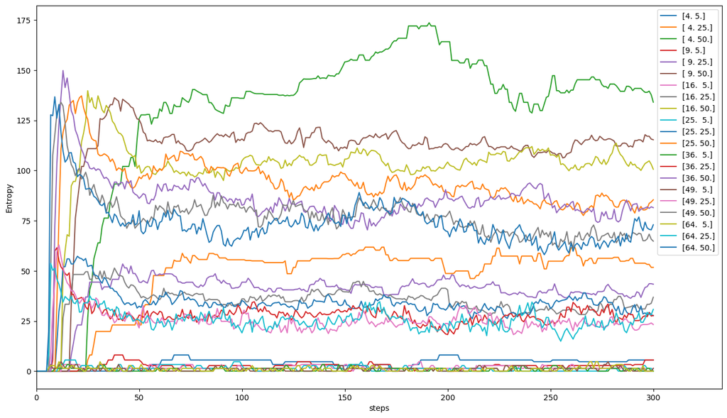

```python
fig, ax = plt.subplots(figsize=(16, 9))
# , color = np.array(['#31c831', '#228b22', '#134e13'])
ax.set_xlim(0,steps+steps/9)
ax.set_xlabel('steps')
ax.set_ylabel('Entropy')
for i, grid in enumerate(N_grid):
    plt.plot(np.column_stack(entropy[i]), label = np.column_stack((np.ones(M_simulation.size)*(i+2)**2,M_simulation)))
plt.legend()
```

This next bit is for plotting an individual p_t(i). So for one time step the probability for i particles.

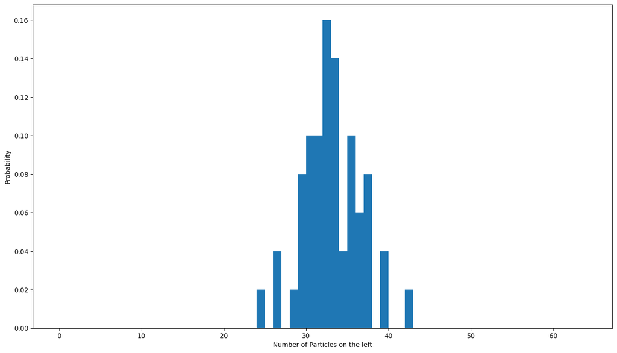

```python
#which time step:
time_step = 300
# how many simulations as an index for M_Simulation
how_many_sim = -1
# How many particles as an index for N_grid
how_many_part = -1

fig, ax = plt.subplots(figsize=(16, 9))
# , color = np.array(['#31c831', '#228b22', '#134e13'])
#ax.set_xlim(0,steps+steps/9)
ax.set_xlabel('steps')
ax.set_ylabel('Particles on the left')


counts, bins = np.histogram(left[how_many_part,how_many_sim,:M_simulation[how_many_sim],time_step], range(0,n_particles[how_many_part]+1))

# print(counts,bins)

ax.hist(bins[:-1], bins, weights=counts/M_simulation[how_many_sim])
ax.set_xlabel('Number of Particles on the left')
ax.set_ylabel('Probability')
```

Plotting for each individual combination of N and M, the amount of particles over time. legend reads like this: Number of particles, number of simulations.

```python
meaned_left = np.zeros((N_grid.shape[0], M_simulation.shape[0], steps+1))
for i in range(len(M_simulation)):
    meaned_left[:,i,:] = np.mean(left[:,i,:M_simulation[i],:], axis = 1)
meaned_left.shape
```

```
(7, 3, 301)
```

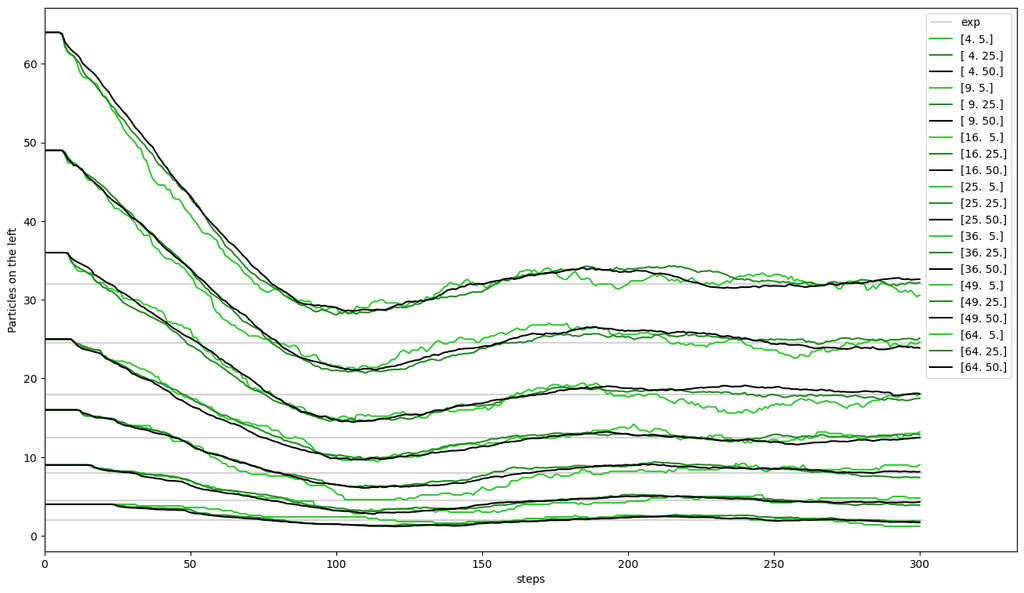

```python
from matplotlib import colors
from pyparsing import alphas


fig, ax = plt.subplots(figsize=(16, 9))
ax.hlines(np.prod(N_grid,axis=1)/2, xmin=0, xmax=steps+1, colors='lightgrey', label='exp')
ax.set_prop_cycle(color=['#31c831', '#228b22', 'black']) #  '#134e13',
for i in range(N_grid.shape[0]):
    ax.plot(np.column_stack(meaned_left[i,:,:]), label = np.column_stack((np.ones(M_simulation.size)*(i+2)**2,M_simulation)))
# , color = np.array(['#31c831', '#228b22', '#134e13'])
ax.set_xlim(0,steps+steps/9)
ax.set_xlabel('steps')
ax.set_ylabel('Particles on the left')
plt.legend()
```

As a sanity check we plot the same for the number of particles on the right

```python
meaned_right = np.zeros((N_grid.shape[0], M_simulation.shape[0], steps+1))
for i in range(len(M_simulation)):
    meaned_right[:,i,:] = np.mean(right[:,i,:M_simulation[i],:], axis = 1)
meaned_right.shape
```

```
(7, 3, 301)
```

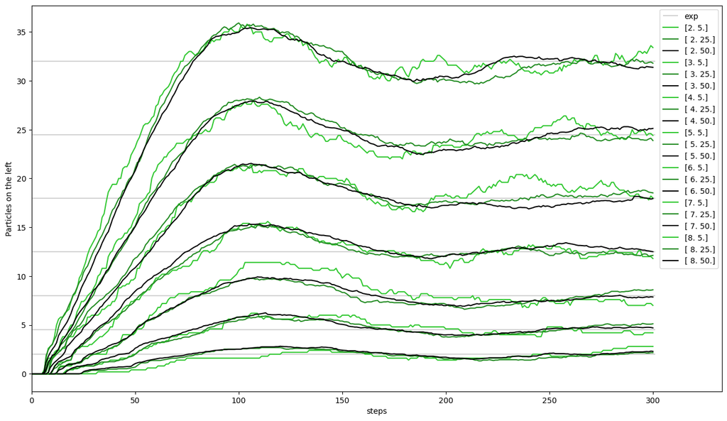

```python
fig, ax = plt.subplots(figsize=(16, 9))
ax.hlines(np.prod(N_grid,axis=1)/2, xmin=0, xmax=steps+1, colors='lightgrey', label='exp')
ax.set_prop_cycle(color=['#31c831', '#228b22', 'black']) #  '#134e13',
for i in range(N_grid.shape[0]):
    ax.plot(np.column_stack(meaned_right[i,:,:]), label = np.column_stack((np.ones(M_simulation.size)*(i+2),M_simulation)))
# , color = np.array(['#31c831', '#228b22', '#134e13'])
ax.set_xlim(0,steps+steps/9)
ax.set_xlabel('steps')
ax.set_ylabel('Particles on the left')
plt.legend()
```

### Task I

Implementing the random walk: We generate all random numbers at once in a (number_of_particles, steps)-size array. This is then converted to either -1 or 1, giving us the change of the random walk instead of an actual random walk. To evaluate at any given position we only need to sum to this position. This speeds up the code significantly if we only evaluate at few positions

```python
def plot_random_walk(state, stats):
    print(state.shape)
    plt.hist(state)
    print('mean: %0.2f, variance: %0.2f, skewness: %0.2f' % stats)
    plt.show()

def random_walk(n_particles, steps):
    random_numbers = np.random.rand(n_particles, steps)
    random_integers = np.where(random_numbers<0.5, -1, 1)
    return random_integers
```

### Task II

Define the parameters

```python
n_particles = [10,100,1000,10000]
steps = 20000
intermediate = [100,1000,10000,20000]
```

Actually run the simulations

```python
stats = np.zeros((len(n_particles), len(intermediate), 3))
random_walks = np.zeros((len(n_particles)))
for k in range(stats.shape[0]):
    final_state = random_walk(n_particles[k], steps)
    for j in range(stats.shape[1]):
        middle_state = np.sum(final_state[:,:intermediate[j]], axis = 1)
        stats[k,j,:] = np.array([np.mean(middle_state), np.var(middle_state), scy.stats.skew(middle_state)])
```

Plotting the mean

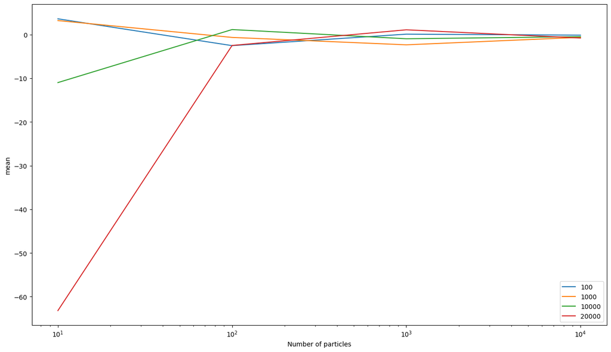

```python
fig, ax = plt.subplots(figsize=(16, 9))
ax.plot(n_particles, stats[:,:,0], label = intermediate)
ax.set_ylabel('mean')
ax.set_xlabel('Number of particles')
ax.set_xscale('log')
plt.legend()
```

In the above visualisation it can be observed that the first moment, mean goes towards zero for large number of particles for all different numbers of steps.

Plotting the variance

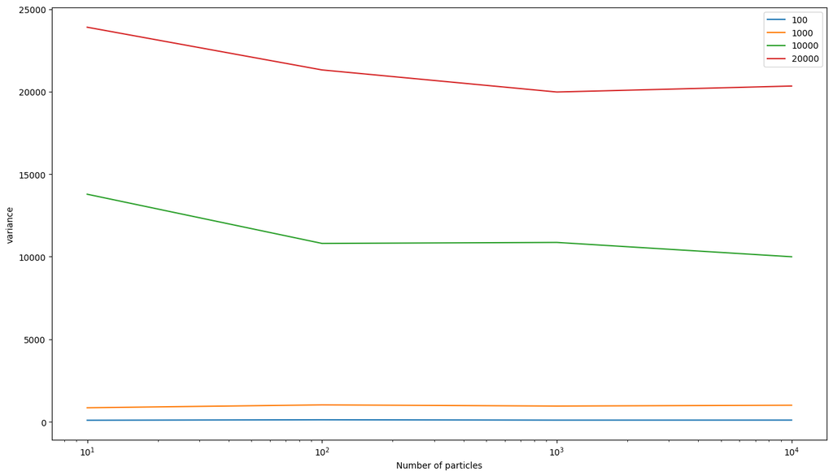

```python
fig, ax = plt.subplots(figsize=(16, 9))
ax.plot(n_particles, stats[:,:,1], label = intermediate)
ax.set_ylabel('variance')
ax.set_xlabel('Number of particles')
ax.set_xscale('log')
plt.legend()
```

Plotting the skew

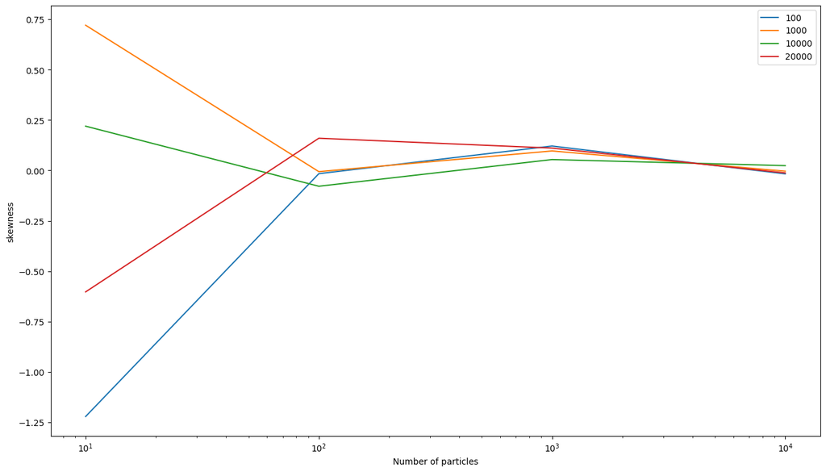

```python
fig, ax = plt.subplots(figsize=(16, 9))
ax.plot(n_particles, stats[:,:,2], label = intermediate)
ax.set_ylabel('skewness')
ax.set_xlabel('Number of particles')
ax.set_xscale('log')
plt.legend()
```

It can be observed that the third moment, giving the skewness goes towards a value of zero as the number of particles increases regardless of the number of steps used.